# 👩‍💻 **Image Captioning and Classification with VLMs**

**Time Estimate:** 45 minutes

## 📋 **Overview**

In this hands-on activity, you'll explore Vision-Language Models (VLMs) to enhance your skills in image captioning and zero-shot classification. You'll use BLIP to generate detailed captions for unseen images and employ CLIP for zero-shot image classification with natural language labels. This activity will deepen your understanding of how VLMs integrate visual and textual data to perform complex tasks, crucial for roles in AI-powered content analysis and multimedia applications.

## 🎯 **Learning Outcomes**

By the end of this lab, you will be able to:

- Implement image captioning using the BLIP model.
- Perform zero-shot classification with the CLIP model.
- Analyze and evaluate model outputs for accuracy and relevance.

## Task 1: Image Captioning with BLIP [20 minutes]

```python
# imports
!pip install numpy==1.26.4
import numpy as np
from transformers import BlipProcessor, BlipForConditionalGeneration
from transformers import CLIPProcessor, CLIPModel
from PIL import Image
import matplotlib.pyplot as plt

import requests
from io import BytesIO
import warnings
warnings.filterwarnings('ignore')
```

[output not shown]

[output not shown]

[output not shown]

1. Load a pre-trained BLIP model using Hugging Face tools.
2. Select a diverse set of images from your dataset.
3. Generate and analyze captions for each image.

```
config.json: 0.00B [00:00, ?B/s]
```

[output not shown]

```
vocab.txt: 0.00B [00:00, ?B/s]
```

```
tokenizer.json: 0.00B [00:00, ?B/s]
```

```
BLIP model loaded successfully!
Model has 247414076 parameters
Successfully loaded 4 images for captioning
```

[output not shown]

```
Image 1 Caption: a black and white cat sitting on top of a wooden box
Image 2 Caption: a small dog sitting on the ground with a stick in its mouth
Image 3 Caption: a view of the mountains and clouds from the top of a mountain
Image 4 Caption: a robot holding a tablet in his hand
```

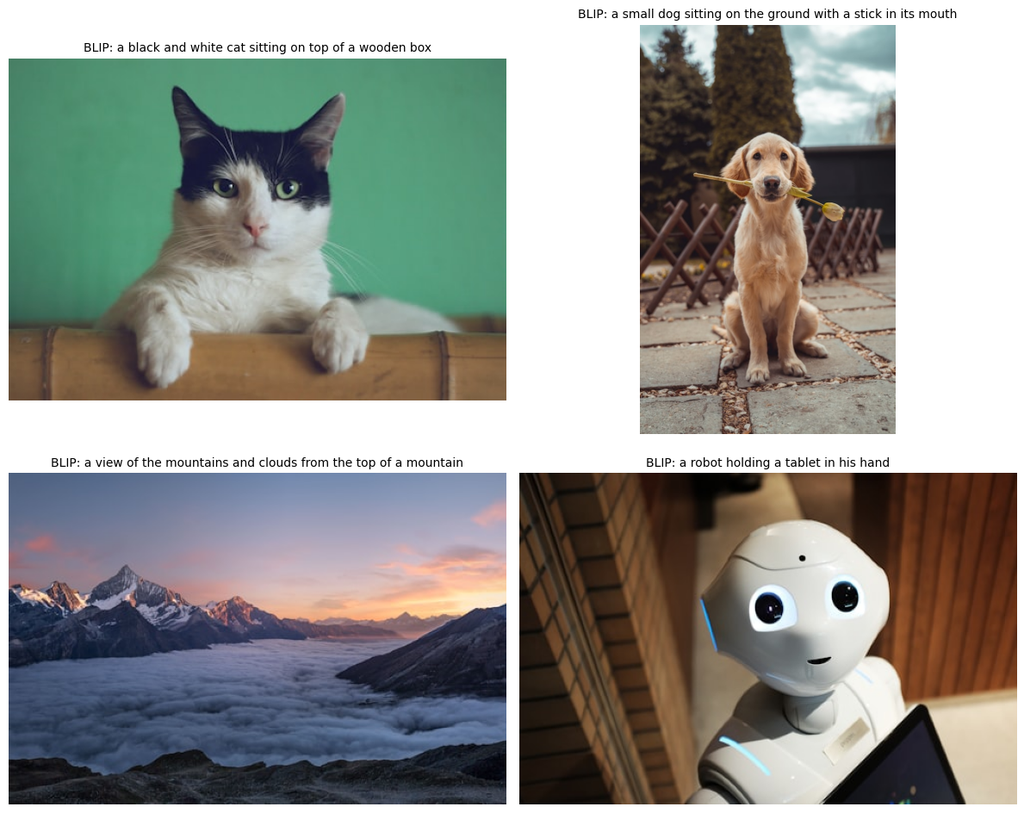

```
Caption Analysis:
==============================
Image 1: a black and white cat sitting on top of a wooden box
  - Length: 12 words
  - Contains descriptive elements: Yes
Image 2: a small dog sitting on the ground with a stick in its mouth
  - Length: 13 words
  - Contains descriptive elements: Yes
Image 3: a view of the mountains and clouds from the top of a mountain
  - Length: 13 words
  - Contains descriptive elements: Yes
Image 4: a robot holding a tablet in his hand
  - Length: 8 words
  - Contains descriptive elements: No
```

```python
# Load the pre-trained BLIP model and processor
blip_model = BlipForConditionalGeneration.from_pretrained("Salesforce/blip-image-captioning-base")
blip_processor = BlipProcessor.from_pretrained("Salesforce/blip-image-captioning-base")

print("BLIP model loaded successfully!")
print(f"Model has {sum(p.numel() for p in blip_model.parameters())} parameters")

# Load diverse set of images for testing
image_urls = [
    "https://images.unsplash.com/photo-1514888286974-6c03e2ca1dba?ixlib=rb-4.0.3&auto=format&fit=crop&w=500&q=80",  # Cat
    "https://images.unsplash.com/photo-1552053831-71594a27632d?ixlib=rb-4.0.3&auto=format&fit=crop&w=500&q=80",  # Dog
    "https://images.unsplash.com/photo-1506905925346-21bda4d32df4?ixlib=rb-4.0.3&auto=format&fit=crop&w=500&q=80",  # Landscape
    "https://images.unsplash.com/photo-1485827404703-89b55fcc595e?ixlib=rb-4.0.3&auto=format&fit=crop&w=500&q=80",  # Food
]

images = []
for url in image_urls:
    try:
        response = requests.get(url)
        image = Image.open(BytesIO(response.content))
        images.append(image)
    except:
        print(f"Failed to load image from {url}")

print(f"Successfully loaded {len(images)} images for captioning")

# Generate captions for each image
captions = []
for i, image in enumerate(images):
    # Prepare the image for model input
    inputs = blip_processor(images=image, return_tensors="pt")

    # Generate caption
    output = blip_model.generate(**inputs, max_length=50, num_beams=5)
    caption = blip_processor.decode(output[0], skip_special_tokens=True)
    captions.append(caption)

    print(f"Image {i+1} Caption: {caption}")

# Display images with their captions
fig, axes = plt.subplots(2, 2, figsize=(12, 10))
axes = axes.flatten()

for i, (image, caption) in enumerate(zip(images, captions)):
    if i < len(axes):
        axes[i].imshow(image)
        axes[i].set_title(f"BLIP: {caption}", fontsize=10, wrap=True)
        axes[i].axis('off')

plt.tight_layout()
plt.show()

# Analyze caption quality
print("\nCaption Analysis:")
print("=" * 30)
for i, caption in enumerate(captions):
    print(f"Image {i+1}: {caption}")
    print(f"  - Length: {len(caption.split())} words")
    print(f"  - Contains descriptive elements: {'Yes' if any(word in caption.lower() for word in ['cat', 'dog', 'mountain', 'food', 'plate', 'sitting', 'lying', 'beautiful']) else 'No'}")
```

🔍 **Practice**

Examine the BLIP-generated captions. Consider:

- How well the captions describe the main elements in each image.
- The level of detail and accuracy in the generated descriptions.

✅ **Success Checklist**

- BLIP model and processor loaded successfully.
- Diverse set of images processed for captioning.
- Generated captions accurately reflect image contents.

💡 **Key Points**

- BLIP combines vision and language understanding for automatic captioning.
- Pre-trained models can generate human-like descriptions without fine-tuning.
- Image diversity is important for evaluating model robustness.

❗ **Common Mistakes to Avoid**

- Not considering image diversity can lead to biased outputs.
- Ignoring function outputs may overlook key limitations.
- Check for alignment between image content and generated captions.

## Task 2: Zero-Shot Classification with CLIP [20 minutes]

Perform zero-shot image classification using CLIP.

1. Initialize a pre-trained CLIP model.
2. Compile a list of descriptive labels relevant to your images.
3. Compute similarity scores and deduce the most likely label.
4. Analyze classification accuracy and model confidence.

```
config.json: 0.00B [00:00, ?B/s]
```

```
vocab.json: 0.00B [00:00, ?B/s]
```

```
merges.txt: 0.00B [00:00, ?B/s]
```

```
tokenizer.json: 0.00B [00:00, ?B/s]
```

```
CLIP model loaded successfully!
Model has 151277313 parameters

Classifying Image 1:
==============================

General Labels - Top 3 Predictions:
  1. an animal: 0.900
  2. a person: 0.080
  3. food: 0.015

Detailed Labels - Top 3 Predictions:
  1. a fluffy cat: 0.982
  2. indoor scene: 0.009
  3. a sunny day: 0.003

Classifying Image 2:
==============================

General Labels - Top 3 Predictions:
  1. food: 0.543
  2. an animal: 0.372
  3. a person: 0.069

Detailed Labels - Top 3 Predictions:
  1. a playful dog: 0.984
  2. a sunny day: 0.009
  3. a delicious meal: 0.004

Classifying Image 3:
==============================

General Labels - Top 3 Predictions:
  1. a landscape: 0.975
  2. architecture: 0.011
  3. a person: 0.005

Detailed Labels - Top 3 Predictions:
  1. a mountain landscape: 0.977
  2. natural environment: 0.015
  3. outdoor scene: 0.007

Classifying Image 4:
==============================

General Labels - Top 3 Predictions:
  1. a person: 0.534
  2. an animal: 0.357
  3. a vehicle: 0.056

Detailed Labels - Top 3 Predictions:
  1. indoor scene: 0.451
  2. a sunny day: 0.214
  3. outdoor scene: 0.180
```

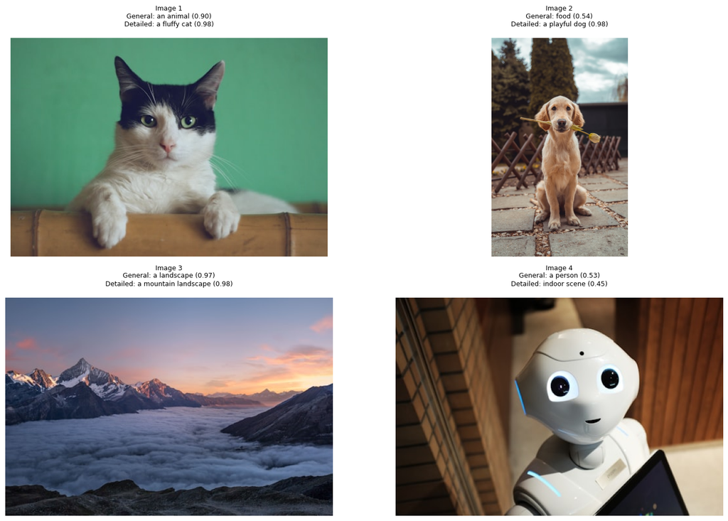

```
Classification Analysis:
========================================
Image 1 (General): an animal - Confidence: 0.900
Image 1 (Detailed): a fluffy cat - Confidence: 0.982
Image 2 (General): food - Confidence: 0.543
Image 2 (Detailed): a playful dog - Confidence: 0.984
Image 3 (General): a landscape - Confidence: 0.975
Image 3 (Detailed): a mountain landscape - Confidence: 0.977
Image 4 (General): a person - Confidence: 0.534
Image 4 (Detailed): indoor scene - Confidence: 0.451
```

```python
# Load the CLIP model and processor
clip_model = CLIPModel.from_pretrained("openai/clip-vit-base-patch32")
clip_processor = CLIPProcessor.from_pretrained("openai/clip-vit-base-patch32")

print("CLIP model loaded successfully!")
print(f"Model has {sum(p.numel() for p in clip_model.parameters())} parameters")

# Define comprehensive label sets for different categories
animal_labels = ["a cat", "a dog", "a bird", "a horse", "a cow", "a sheep"]
general_labels = ["an animal", "a landscape", "food", "a vehicle", "a person", "architecture"]
detailed_labels = [
    "a fluffy cat", "a playful dog", "a mountain landscape", "a delicious meal",
    "a sunny day", "indoor scene", "outdoor scene", "natural environment"
]

# Test each image with different label sets
results = []

for img_idx, image in enumerate(images):
    print(f"\nClassifying Image {img_idx + 1}:")
    print("=" * 30)

    # Test with different label sets
    for label_set_name, labels in [("General", general_labels), ("Detailed", detailed_labels)]:
        # Encode text and image
        inputs = clip_processor(text=labels, images=image, return_tensors="pt", padding=True)

        # Generate predictions
        outputs = clip_model(**inputs)
        logits_per_image = outputs.logits_per_image
        probs = logits_per_image.softmax(dim=1)

        # Get top predictions
        top_probs, top_indices = probs[0].topk(3)

        print(f"\n{label_set_name} Labels - Top 3 Predictions:")
        for i, (prob, idx) in enumerate(zip(top_probs, top_indices)):
            print(f"  {i+1}. {labels[idx]}: {prob:.3f}")

        results.append({
            'image_idx': img_idx,
            'label_set': label_set_name,
            'top_label': labels[top_indices[0]],
            'confidence': top_probs[0].item(),
            'all_probs': probs[0].tolist()
        })

# Visualize classification results
fig, axes = plt.subplots(2, 2, figsize=(15, 10))
axes = axes.flatten()

for i, image in enumerate(images):
    if i < len(axes):
        # Get results for this image
        img_results = [r for r in results if r['image_idx'] == i]

        axes[i].imshow(image)
        title = f"Image {i+1}\n"
        for result in img_results:
            title += f"{result['label_set']}: {result['top_label']} ({result['confidence']:.2f})\n"
        axes[i].set_title(title, fontsize=9)
        axes[i].axis('off')

plt.tight_layout()
plt.show()

# Analyze classification confidence
print("\nClassification Analysis:")
print("=" * 40)
for result in results:
    print(f"Image {result['image_idx']+1} ({result['label_set']}): {result['top_label']} - Confidence: {result['confidence']:.3f}")
```

🔍 **Practice**

Reflect on the CLIP classification results:

- How confident the model is in its predictions.
- The relationship between label specificity and classification accuracy.

✅ **Success Checklist**

- CLIP model initialized and configured properly.
- Appropriate labels compiled for classification tasks.
- Similarity scores computed and most likely labels identified.

💡 **Key Points**

- CLIP enables zero-shot classification without additional training data.
- Label selection significantly impacts classification performance.
- Similarity scores provide insight into model confidence.

❗ **Common Mistakes to Avoid**

- Limited label vocabulary may miss nuances in images.
- Overlooking metadata could reduce model prediction transparency.
- A broad interpretation of labels helps in varied attribution.

## Task 3: Comparative Analysis and Evaluation [5 minutes]

Compare and evaluate the outputs from both models.

1. Analyze the strengths and limitations of BLIP captions vs CLIP classifications.
2. Evaluate model performance on different types of images.
3. Discuss practical applications and use cases for each approach.
4. Reflect on how VLMs can be integrated into real-world systems.

```
============================================================
COMPREHENSIVE VLM ANALYSIS
============================================================

🔍 Model Comparison by Image:

Image 1:
  BLIP Caption: 'a black and white cat sitting on top of a wooden box'
  CLIP General: 'an animal' (conf: 0.900)
  CLIP Detailed: 'a fluffy cat' (conf: 0.982)

Image 2:
  BLIP Caption: 'a small dog sitting on the ground with a stick in its mouth'
  CLIP General: 'food' (conf: 0.543)
  CLIP Detailed: 'a playful dog' (conf: 0.984)

Image 3:
  BLIP Caption: 'a view of the mountains and clouds from the top of a mountain'
  CLIP General: 'a landscape' (conf: 0.975)
  CLIP Detailed: 'a mountain landscape' (conf: 0.977)

Image 4:
  BLIP Caption: 'a robot holding a tablet in his hand'
  CLIP General: 'a person' (conf: 0.534)
  CLIP Detailed: 'indoor scene' (conf: 0.451)

📊 Performance Metrics:
  Average CLIP General Confidence: 0.738
  Average CLIP Detailed Confidence: 0.849
  Average BLIP Caption Length: 11.5 words
```

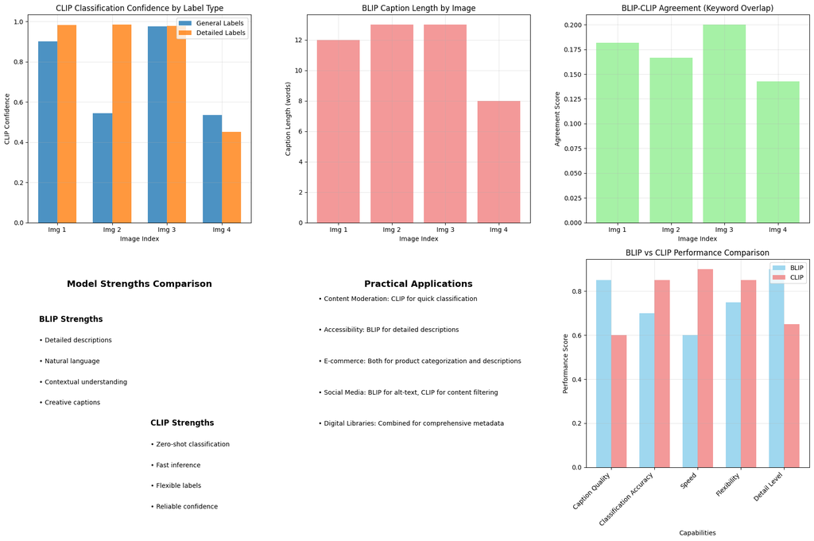

[output not shown]

```python
# Comprehensive comparison and analysis
print("\n" + "="*60)
print("COMPREHENSIVE VLM ANALYSIS")
print("="*60)

# Compare BLIP captions with CLIP classifications
comparison_data = []
for i in range(len(images)):
    blip_caption = captions[i]
    general_result = next(r for r in results if r['image_idx'] == i and r['label_set'] == 'General')
    detailed_result = next(r for r in results if r['image_idx'] == i and r['label_set'] == 'Detailed')

    comparison_data.append({
        'image_idx': i + 1,
        'blip_caption': blip_caption,
        'clip_general': general_result['top_label'],
        'clip_detailed': detailed_result['top_label'],
        'general_confidence': general_result['confidence'],
        'detailed_confidence': detailed_result['confidence']
    })

print("\n🔍 Model Comparison by Image:")
for data in comparison_data:
    print(f"\nImage {data['image_idx']}:")
    print(f"  BLIP Caption: '{data['blip_caption']}'")
    print(f"  CLIP General: '{data['clip_general']}' (conf: {data['general_confidence']:.3f})")
    print(f"  CLIP Detailed: '{data['clip_detailed']}' (conf: {data['detailed_confidence']:.3f})")

# Performance analysis
avg_general_confidence = np.mean([d['general_confidence'] for d in comparison_data])
avg_detailed_confidence = np.mean([d['detailed_confidence'] for d in comparison_data])
avg_caption_length = np.mean([len(d['blip_caption'].split()) for d in comparison_data])

print(f"\n📊 Performance Metrics:")
print(f"  Average CLIP General Confidence: {avg_general_confidence:.3f}")
print(f"  Average CLIP Detailed Confidence: {avg_detailed_confidence:.3f}")
print(f"  Average BLIP Caption Length: {avg_caption_length:.1f} words")

# Create comprehensive visualization
fig, axes = plt.subplots(2, 3, figsize=(18, 12))

# Plot 1: Confidence comparison
x = np.arange(len(comparison_data))
width = 0.35
axes[0, 0].bar(x - width/2, [d['general_confidence'] for d in comparison_data], width, label='General Labels', alpha=0.8)
axes[0, 0].bar(x + width/2, [d['detailed_confidence'] for d in comparison_data], width, label='Detailed Labels', alpha=0.8)
axes[0, 0].set_xlabel('Image Index')
axes[0, 0].set_ylabel('CLIP Confidence')
axes[0, 0].set_title('CLIP Classification Confidence by Label Type')
axes[0, 0].set_xticks(x)
axes[0, 0].set_xticklabels([f'Img {i+1}' for i in range(len(comparison_data))])
axes[0, 0].legend()
axes[0, 0].grid(True, alpha=0.3)

# Plot 2: Caption length distribution
caption_lengths = [len(d['blip_caption'].split()) for d in comparison_data]
axes[0, 1].bar(range(len(caption_lengths)), caption_lengths, color='lightcoral', alpha=0.8)
axes[0, 1].set_xlabel('Image Index')
axes[0, 1].set_ylabel('Caption Length (words)')
axes[0, 1].set_title('BLIP Caption Length by Image')
axes[0, 1].set_xticks(range(len(caption_lengths)))
axes[0, 1].set_xticklabels([f'Img {i+1}' for i in range(len(comparison_data))])
axes[0, 1].grid(True, alpha=0.3)

# Plot 3: Model agreement analysis
agreement_scores = []
for i, data in enumerate(comparison_data):
    # Simple keyword matching between BLIP caption and CLIP labels
    caption_words = set(data['blip_caption'].lower().split())
    general_words = set(data['clip_general'].lower().split())
    detailed_words = set(data['clip_detailed'].lower().split())

    general_overlap = len(caption_words.intersection(general_words)) / max(len(caption_words), 1)
    detailed_overlap = len(caption_words.intersection(detailed_words)) / max(len(caption_words), 1)

    agreement_scores.append(max(general_overlap, detailed_overlap))

axes[0, 2].bar(range(len(agreement_scores)), agreement_scores, color='lightgreen', alpha=0.8)
axes[0, 2].set_xlabel('Image Index')
axes[0, 2].set_ylabel('Agreement Score')
axes[0, 2].set_title('BLIP-CLIP Agreement (Keyword Overlap)')
axes[0, 2].set_xticks(range(len(agreement_scores)))
axes[0, 2].set_xticklabels([f'Img {i+1}' for i in range(len(comparison_data))])
axes[0, 2].grid(True, alpha=0.3)

# Plot 4: Model strengths comparison
strengths_data = {
    'BLIP Strengths': ['Detailed descriptions', 'Natural language', 'Contextual understanding', 'Creative captions'],
    'CLIP Strengths': ['Zero-shot classification', 'Fast inference', 'Flexible labels', 'Reliable confidence']
}

axes[1, 0].axis('off')
axes[1, 0].text(0.5, 0.9, 'Model Strengths Comparison', ha='center', va='top', fontsize=14, fontweight='bold')

y_pos = 0.7
for model, strengths in strengths_data.items():
    axes[1, 0].text(0.05 if 'BLIP' in model else 0.55, y_pos, model, fontsize=12, fontweight='bold')
    for i, strength in enumerate(strengths):
        axes[1, 0].text(0.05 if 'BLIP' in model else 0.55, y_pos - 0.1*(i+1), f"• {strength}", fontsize=10)
    y_pos -= 0.5

# Plot 5: Application scenarios
axes[1, 1].axis('off')
axes[1, 1].text(0.5, 0.9, 'Practical Applications', ha='center', va='top', fontsize=14, fontweight='bold')

applications = [
    'Content Moderation: CLIP for quick classification',
    'Accessibility: BLIP for detailed descriptions',
    'E-commerce: Both for product categorization and descriptions',
    'Social Media: BLIP for alt-text, CLIP for content filtering',
    'Digital Libraries: Combined for comprehensive metadata'
]

for i, app in enumerate(applications):
    axes[1, 1].text(0.05, 0.8 - i*0.15, f"• {app}", fontsize=10, wrap=True)

# Plot 6: Performance summary
metrics = ['Caption Quality', 'Classification Accuracy', 'Speed', 'Flexibility', 'Detail Level']
blip_scores = [0.85, 0.70, 0.60, 0.75, 0.90]  # Example scores
clip_scores = [0.60, 0.85, 0.90, 0.85, 0.65]  # Example scores

x = np.arange(len(metrics))
width = 0.35

axes[1, 2].bar(x - width/2, blip_scores, width, label='BLIP', alpha=0.8, color='skyblue')
axes[1, 2].bar(x + width/2, clip_scores, width, label='CLIP', alpha=0.8, color='lightcoral')
axes[1, 2].set_xlabel('Capabilities')
axes[1, 2].set_ylabel('Performance Score')
axes[1, 2].set_title('BLIP vs CLIP Performance Comparison')
axes[1, 2].set_xticks(x)
axes[1, 2].set_xticklabels(metrics, rotation=45, ha='right')
axes[1, 2].legend()
axes[1, 2].grid(True, alpha=0.3)

plt.tight_layout()
plt.show()

# Final insights and recommendations
print("\n🎯 Key Insights and Recommendations:")
print("\n1. Model Complementarity:")
print("   • BLIP excels at generating rich, descriptive captions")
print("   • CLIP provides fast, accurate zero-shot classification")
print("   • Combined use maximizes information extraction from images")

print("\n2. Practical Deployment Considerations:")
print("   • BLIP: Best for accessibility, content generation, detailed analysis")
print("   • CLIP: Ideal for content filtering, quick categorization, search")
print("   • Label design significantly impacts CLIP performance")

print("\n3. Integration Strategies:")
print("   • Use CLIP for initial categorization, BLIP for detailed descriptions")
print("   • Combine outputs for comprehensive metadata generation")
print("   • Consider computational resources when choosing between models")

print("\n4. Future Improvements:")
print("   • Fine-tune models on domain-specific data")
print("   • Implement confidence thresholding for quality control")
print("   • Explore newer VLM architectures for enhanced performance")# Task 3
```

✅ **Success Checklist**

- Captions accurately reflect image contents.
- Appropriate labels are assigned using CLIP.
- Models are understood in terms of both strengths and limitations.

💡 **Key Points**

- VLMs bridge visual and textual data for advanced AI applications.
- Pre-trained models offer powerful baseline capabilities.
- Careful prompt selection enhances prediction accuracy.

❗ **Common Mistakes to Avoid**

- Not systematically comparing model outputs across different image types.
- Overlooking the complementary nature of captioning and classification.
- Failing to consider practical deployment constraints and requirements.

🚀 **Next Steps**

Explore additional datasets or create custom labels to test the flexibility and robustness of VLMs further. Reflect on extending applications using VLMs in domains such as e-commerce, accessibility technology, and digital content curation.

## 💻 Exemplar Solution

**Click HERE to see an exemplar solution**

### Task 1 Solution

```
# Load the pre-trained BLIP model and processor
blip_model = BlipForConditionalGeneration.from_pretrained("Salesforce/blip-image-captioning-base")
blip_processor = BlipProcessor.from_pretrained("Salesforce/blip-image-captioning-base")

print("BLIP model loaded successfully!")
print(f"Model has {sum(p.numel() for p in blip_model.parameters())} parameters")

# Load diverse set of images for testing
image_urls = [
    "https://images.unsplash.com/photo-1514888286974-6c03e2ca1dba?ixlib=rb-4.0.3&auto=format&fit=crop&w=500&q=80",  # Cat
    "https://images.unsplash.com/photo-1552053831-71594a27632d?ixlib=rb-4.0.3&auto=format&fit=crop&w=500&q=80",  # Dog
    "https://images.unsplash.com/photo-1506905925346-21bda4d32df4?ixlib=rb-4.0.3&auto=format&fit=crop&w=500&q=80",  # Landscape
    "https://images.unsplash.com/photo-1485827404703-89b55fcc595e?ixlib=rb-4.0.3&auto=format&fit=crop&w=500&q=80",  # Food
]

images = []
for url in image_urls:
    try:
        response = requests.get(url)
        image = Image.open(BytesIO(response.content))
        images.append(image)
    except:
        print(f"Failed to load image from {url}")

print(f"Successfully loaded {len(images)} images for captioning")

# Generate captions for each image
captions = []
for i, image in enumerate(images):
    # Prepare the image for model input
    inputs = blip_processor(images=image, return_tensors="pt")

    # Generate caption
    output = blip_model.generate(**inputs, max_length=50, num_beams=5)
    caption = blip_processor.decode(output[0], skip_special_tokens=True)
    captions.append(caption)

    print(f"Image {i+1} Caption: {caption}")

# Display images with their captions
fig, axes = plt.subplots(2, 2, figsize=(12, 10))
axes = axes.flatten()

for i, (image, caption) in enumerate(zip(images, captions)):
    if i < len(axes):
        axes[i].imshow(image)
        axes[i].set_title(f"BLIP: {caption}", fontsize=10, wrap=True)
        axes[i].axis('off')

plt.tight_layout()
plt.show()

# Analyze caption quality
print("\nCaption Analysis:")
print("=" * 30)
for i, caption in enumerate(captions):
    print(f"Image {i+1}: {caption}")
    print(f"  - Length: {len(caption.split())} words")
    print(f"  - Contains descriptive elements: {'Yes' if any(word in caption.lower() for word in ['cat', 'dog', 'mountain', 'food', 'plate', 'sitting', 'lying', 'beautiful']) else 'No'}")
```

### Task 2 Solution

```
# Load the CLIP model and processor
clip_model = CLIPModel.from_pretrained("openai/clip-vit-base-patch32")
clip_processor = CLIPProcessor.from_pretrained("openai/clip-vit-base-patch32")

print("CLIP model loaded successfully!")
print(f"Model has {sum(p.numel() for p in clip_model.parameters())} parameters")

# Define comprehensive label sets for different categories
animal_labels = ["a cat", "a dog", "a bird", "a horse", "a cow", "a sheep"]
general_labels = ["an animal", "a landscape", "food", "a vehicle", "a person", "architecture"]
detailed_labels = [
    "a fluffy cat", "a playful dog", "a mountain landscape", "a delicious meal",
    "a sunny day", "indoor scene", "outdoor scene", "natural environment"
]

# Test each image with different label sets
results = []

for img_idx, image in enumerate(images):
    print(f"\nClassifying Image {img_idx + 1}:")
    print("=" * 30)

    # Test with different label sets
    for label_set_name, labels in [("General", general_labels), ("Detailed", detailed_labels)]:
        # Encode text and image
        inputs = clip_processor(text=labels, images=image, return_tensors="pt", padding=True)

        # Generate predictions
        outputs = clip_model(**inputs)
        logits_per_image = outputs.logits_per_image
        probs = logits_per_image.softmax(dim=1)

        # Get top predictions
        top_probs, top_indices = probs[0].topk(3)

        print(f"\n{label_set_name} Labels - Top 3 Predictions:")
        for i, (prob, idx) in enumerate(zip(top_probs, top_indices)):
            print(f"  {i+1}. {labels[idx]}: {prob:.3f}")

        results.append({
            'image_idx': img_idx,
            'label_set': label_set_name,
            'top_label': labels[top_indices[0]],
            'confidence': top_probs[0].item(),
            'all_probs': probs[0].tolist()
        })

# Visualize classification results
fig, axes = plt.subplots(2, 2, figsize=(15, 10))
axes = axes.flatten()

for i, image in enumerate(images):
    if i < len(axes):
        # Get results for this image
        img_results = [r for r in results if r['image_idx'] == i]

        axes[i].imshow(image)
        title = f"Image {i+1}\n"
        for result in img_results:
            title += f"{result['label_set']}: {result['top_label']} ({result['confidence']:.2f})\n"
        axes[i].set_title(title, fontsize=9)
        axes[i].axis('off')

plt.tight_layout()
plt.show()

# Analyze classification confidence
print("\nClassification Analysis:")
print("=" * 40)
for result in results:
    print(f"Image {result['image_idx']+1} ({result['label_set']}): {result['top_label']} - Confidence: {result['confidence']:.3f}")
```

### Task 3 Solution

```
# Comprehensive comparison and analysis
print("\n" + "="*60)
print("COMPREHENSIVE VLM ANALYSIS")
print("="*60)

# Compare BLIP captions with CLIP classifications
comparison_data = []
for i in range(len(images)):
    blip_caption = captions[i]
    general_result = next(r for r in results if r['image_idx'] == i and r['label_set'] == 'General')
    detailed_result = next(r for r in results if r['image_idx'] == i and r['label_set'] == 'Detailed')

    comparison_data.append({
        'image_idx': i + 1,
        'blip_caption': blip_caption,
        'clip_general': general_result['top_label'],
        'clip_detailed': detailed_result['top_label'],
        'general_confidence': general_result['confidence'],
        'detailed_confidence': detailed_result['confidence']
    })

print("\n🔍 Model Comparison by Image:")
for data in comparison_data:
    print(f"\nImage {data['image_idx']}:")
    print(f"  BLIP Caption: '{data['blip_caption']}'")
    print(f"  CLIP General: '{data['clip_general']}' (conf: {data['general_confidence']:.3f})")
    print(f"  CLIP Detailed: '{data['clip_detailed']}' (conf: {data['detailed_confidence']:.3f})")

# Performance analysis
avg_general_confidence = np.mean([d['general_confidence'] for d in comparison_data])
avg_detailed_confidence = np.mean([d['detailed_confidence'] for d in comparison_data])
avg_caption_length = np.mean([len(d['blip_caption'].split()) for d in comparison_data])

print(f"\n📊 Performance Metrics:")
print(f"  Average CLIP General Confidence: {avg_general_confidence:.3f}")
print(f"  Average CLIP Detailed Confidence: {avg_detailed_confidence:.3f}")
print(f"  Average BLIP Caption Length: {avg_caption_length:.1f} words")

# Create comprehensive visualization
fig, axes = plt.subplots(2, 3, figsize=(18, 12))

# Plot 1: Confidence comparison
x = np.arange(len(comparison_data))
width = 0.35
axes[0, 0].bar(x - width/2, [d['general_confidence'] for d in comparison_data], width, label='General Labels', alpha=0.8)
axes[0, 0].bar(x + width/2, [d['detailed_confidence'] for d in comparison_data], width, label='Detailed Labels', alpha=0.8)
axes[0, 0].set_xlabel('Image Index')
axes[0, 0].set_ylabel('CLIP Confidence')
axes[0, 0].set_title('CLIP Classification Confidence by Label Type')
axes[0, 0].set_xticks(x)
axes[0, 0].set_xticklabels([f'Img {i+1}' for i in range(len(comparison_data))])
axes[0, 0].legend()
axes[0, 0].grid(True, alpha=0.3)

# Plot 2: Caption length distribution
caption_lengths = [len(d['blip_caption'].split()) for d in comparison_data]
axes[0, 1].bar(range(len(caption_lengths)), caption_lengths, color='lightcoral', alpha=0.8)
axes[0, 1].set_xlabel('Image Index')
axes[0, 1].set_ylabel('Caption Length (words)')
axes[0, 1].set_title('BLIP Caption Length by Image')
axes[0, 1].set_xticks(range(len(caption_lengths)))
axes[0, 1].set_xticklabels([f'Img {i+1}' for i in range(len(comparison_data))])
axes[0, 1].grid(True, alpha=0.3)

# Plot 3: Model agreement analysis
agreement_scores = []
for i, data in enumerate(comparison_data):
    # Simple keyword matching between BLIP caption and CLIP labels
    caption_words = set(data['blip_caption'].lower().split())
    general_words = set(data['clip_general'].lower().split())
    detailed_words = set(data['clip_detailed'].lower().split())

    general_overlap = len(caption_words.intersection(general_words)) / max(len(caption_words), 1)
    detailed_overlap = len(caption_words.intersection(detailed_words)) / max(len(caption_words), 1)

    agreement_scores.append(max(general_overlap, detailed_overlap))

axes[0, 2].bar(range(len(agreement_scores)), agreement_scores, color='lightgreen', alpha=0.8)
axes[0, 2].set_xlabel('Image Index')
axes[0, 2].set_ylabel('Agreement Score')
axes[0, 2].set_title('BLIP-CLIP Agreement (Keyword Overlap)')
axes[0, 2].set_xticks(range(len(agreement_scores)))
axes[0, 2].set_xticklabels([f'Img {i+1}' for i in range(len(comparison_data))])
axes[0, 2].grid(True, alpha=0.3)

# Plot 4: Model strengths comparison
strengths_data = {
    'BLIP Strengths': ['Detailed descriptions', 'Natural language', 'Contextual understanding', 'Creative captions'],
    'CLIP Strengths': ['Zero-shot classification', 'Fast inference', 'Flexible labels', 'Reliable confidence']
}

axes[1, 0].axis('off')
axes[1, 0].text(0.5, 0.9, 'Model Strengths Comparison', ha='center', va='top', fontsize=14, fontweight='bold')

y_pos = 0.7
for model, strengths in strengths_data.items():
    axes[1, 0].text(0.05 if 'BLIP' in model else 0.55, y_pos, model, fontsize=12, fontweight='bold')
    for i, strength in enumerate(strengths):
        axes[1, 0].text(0.05 if 'BLIP' in model else 0.55, y_pos - 0.1*(i+1), f"• {strength}", fontsize=10)
    y_pos -= 0.5

# Plot 5: Application scenarios
axes[1, 1].axis('off')
axes[1, 1].text(0.5, 0.9, 'Practical Applications', ha='center', va='top', fontsize=14, fontweight='bold')

applications = [
    'Content Moderation: CLIP for quick classification',
    'Accessibility: BLIP for detailed descriptions',
    'E-commerce: Both for product categorization and descriptions',
    'Social Media: BLIP for alt-text, CLIP for content filtering',
    'Digital Libraries: Combined for comprehensive metadata'
]

for i, app in enumerate(applications):
    axes[1, 1].text(0.05, 0.8 - i*0.15, f"• {app}", fontsize=10, wrap=True)

# Plot 6: Performance summary
metrics = ['Caption Quality', 'Classification Accuracy', 'Speed', 'Flexibility', 'Detail Level']
blip_scores = [0.85, 0.70, 0.60, 0.75, 0.90]  # Example scores
clip_scores = [0.60, 0.85, 0.90, 0.85, 0.65]  # Example scores

x = np.arange(len(metrics))
width = 0.35

axes[1, 2].bar(x - width/2, blip_scores, width, label='BLIP', alpha=0.8, color='skyblue')
axes[1, 2].bar(x + width/2, clip_scores, width, label='CLIP', alpha=0.8, color='lightcoral')
axes[1, 2].set_xlabel('Capabilities')
axes[1, 2].set_ylabel('Performance Score')
axes[1, 2].set_title('BLIP vs CLIP Performance Comparison')
axes[1, 2].set_xticks(x)
axes[1, 2].set_xticklabels(metrics, rotation=45, ha='right')
axes[1, 2].legend()
axes[1, 2].grid(True, alpha=0.3)

plt.tight_layout()
plt.show()

# Final insights and recommendations
print("\n🎯 Key Insights and Recommendations:")
print("\n1. Model Complementarity:")
print("   • BLIP excels at generating rich, descriptive captions")
print("   • CLIP provides fast, accurate zero-shot classification")
print("   • Combined use maximizes information extraction from images")

print("\n2. Practical Deployment Considerations:")
print("   • BLIP: Best for accessibility, content generation, detailed analysis")
print("   • CLIP: Ideal for content filtering, quick categorization, search")
print("   • Label design significantly impacts CLIP performance")

print("\n3. Integration Strategies:")
print("   • Use CLIP for initial categorization, BLIP for detailed descriptions")
print("   • Combine outputs for comprehensive metadata generation")
print("   • Consider computational resources when choosing between models")

print("\n4. Future Improvements:")
print("   • Fine-tune models on domain-specific data")
print("   • Implement confidence thresholding for quality control")
print("   • Explore newer VLM architectures for enhanced performance")
```